# Unit 1 Independent Analysis

6/15/2021

## PREPARE

**Context** – this independent analysis builds on the work introduced in our unit 1 walkthrough.

Our walkthrough looked at the social networks in a MOOC-Ed course designed to provide professional development opportunities for educators, supporting their work in developing k-12 digital learning initiatives. This course was offered twice – our walkthrough last week examined the results of the first offering. My independent analysis this week examines the results of the second offering + compares the two.

Kellogg, S., Booth, S., & Oliver, K. (2014). [A social network perspective on peer supported learning in MOOCs for educators.](https://github.com/sbkellogg/eci-589/blob/main/unit-1/lit/sna_mooc_irrodl_bjet_articles.pdf) International Review of Research in Open and Distributed Learning, 15(5), 263-289.

## PREPARE

**Research Questions** – For the walkthrugh, the question we were attempting to answer was:

> *>>To what extent did educators engage with other participants in the discussion forums?*

For this analysis, I am seeking to answer the same question for the second offering of the course. I also want to know…

> *>>Were there differences in engagement across the two cohorts of educators?*

## PREPARE

The packages used for analysis include `igraph` and `tidyverse`.

The data set used will be referred to as DTL 2 and is available [here](https://dataverse.harvard.edu/dataset.xhtml?persistentId=doi:10.7910/DVN/ZZH3UB).

The data consists of demographic info provided by participants upon registration + all forms of peer interaction that took place in the forums (i.e. peer discussion, feedback, and reactions (e.g., likes)).

## WRANGLE

First, we read in the ‘edges’, or, in plain English, all that info related to the the peer-to-peer interaction just mentioned. The ties, or relationships between the actors/individuals.

```
## # A tibble: 2,584 x 8
##    Sender Receiver Timestamp Title Parent Description `Comment ID`
##    <chr>  <chr>    <chr>     <chr> <chr>  <chr>       <chr>
##  1 37     461      9/27/13   Gree… Group… Please int… 3
##  2 434    434      9/27/13   Sher… Group… Please int… 4
##  3 302    434      9/27/13   Sher… Group… Please int… 5
##  4 60     434      9/27/13   Sher… Group… Please int… 7
##  5 128    434      9/29/13   Sher… Group… Please int… 38
##  6 158    434      9/30/13   Sher… Group… Please int… 75
##  7 442    434      10/1/13   Sher… Group… Please int… 193
##  8 43     245      9/27/13   Plan… Group… What would… 6
##  9 426    245      9/30/13   Plan… Group… What would… 146
## 10 142    245      10/1/13   Plan… Group… What would… 201
## # … with 2,574 more rows, and 1 more variable: `Discussion ID` <chr>
```

## WRANGLE

Next, we read in the ‘nodes’, which contains demographic & other info about the actors/individuals

```
## # A tibble: 492 x 13
##    UID   Facilitator role  experience2 experience grades location region country
##    <chr> <chr>       <chr>       <dbl>      <dbl> <chr>  <chr>    <chr>  <chr>
##  1 1     0           curr…           2         17 gener… IN       Midwe… US
##  2 2     0           other           1          3 prima… NC       South  US
##  3 3     0           inst…           2         20 gener… US       South  US
##  4 4     0           inst…           2         12 middle TX       South  US
##  5 5     0           other           1          0 gener… CAN      Inter… CA
##  6 6     0           inst…           1          7 gener… CAN      Inter… CA
##  7 7     0           oper…           1          6 gener… RI       North… US
##  8 8     0           curr…           2         12 middle ME       North… US
##  9 9     0           other           2         11 gener… VA       South  US
## 10 10    0           inst…           3         21 gener… WV       South  US
## # … with 482 more rows, and 4 more variables: group <chr>, gender <chr>,
## #   expert <chr>, connect <chr>
```

## WRANGLE

Next, we’ll combine those two things into a complete network.

We can see that we have 492 actors and 2584 ties – about the same as from the first offering of the course! (445 and 2529, respectively)

```
## IGRAPH dd71480 DN-- 492 2584 --
## + attr: name (v/c), Facilitator (v/c), role (v/c), experience2 (v/n),
## | experience (v/n), grades (v/c), location (v/c), region (v/c), country
## | (v/c), group (v/c), gender (v/c), expert (v/c), connect (v/c),
## | Timestamp (e/c), Title (e/c), Parent (e/c), Description (e/c),
## | Comment ID (e/c), Discussion ID (e/c)
## + edges from dd71480 (vertex names):
##  [1] 37 ->461 434->434 302->434 60 ->434 128->434 158->434 442->434 43 ->245
##  [9] 426->245 142->245 41 ->245 155->245 292->245 110->245 130->245 149->245
## [17] 155->245 157->110 157->245 153->245 158->245 14 ->157 361->245 246->245
## [25] 133->245 176->43  362->43  278->43  184->43  302->300 158->300 302->316
## + ... omitted several edges
```

## WRANGLE

Using the `simplify()` function allows us to remove duplicate ties. From 2584 to 2062.

```
## IGRAPH b508964 DN-- 492 2062 --
## + attr: name (v/c), Facilitator (v/c), role (v/c), experience2 (v/n),
## | experience (v/n), grades (v/c), location (v/c), region (v/c), country
## | (v/c), group (v/c), gender (v/c), expert (v/c), connect (v/c)
## + edges from b508964 (vertex names):
##  [1] 3 ->302 6 ->94  6 ->244 6 ->302 6 ->483 7 ->4   7 ->302 7 ->447 10->321
## [10] 11->245 11->302 12->343 14->33  14->43  14->157 14->170 14->195 14->255
## [19] 14->302 14->396 17->302 18->208 19->157 19->302 19->328 19->361 20->23
## [28] 20->189 20->302 20->430 21->43  21->302 22->33  22->100 22->453 23->17
## [37] 23->24  23->28  23->30  23->33  23->40  23->43  23->50  23->63  23->84
## [46] 23->125 23->135 23->158 23->186 23->195 23->197 23->208 23->213 23->223
## + ... omitted several edges
```

## WRANGLE

We can also add weights to our edges to help us determine how frequently participants interacted with one another. Looks like participant 100 interacted with participant 302 a total of 4 times, for example.

```
## # A tibble: 2,080 x 3
##    Sender Receiver     n
##    <chr>  <chr>    <int>
##  1 10     321          1
##  2 100    100          1
##  3 100    161          1
##  4 100    183          1
##  5 100    22           1
##  6 100    302          4
##  7 100    426          1
##  8 101    300          1
##  9 106    361          1
## 10 107    302          1
## # … with 2,070 more rows
```

## EXPLORE + ANALYZE

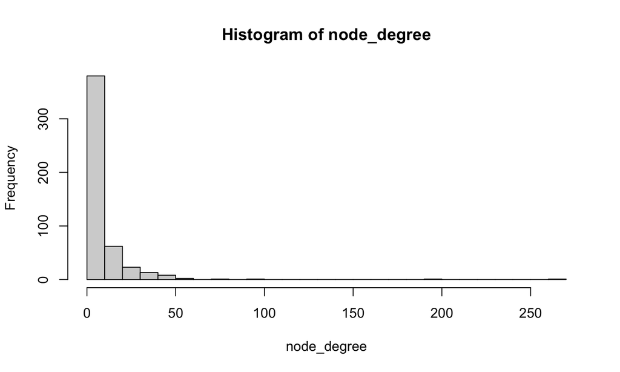

```
## [1] 8.382114
```

```
## [1] 3
```

## EXPLORE + ANALYZE

But, on average, most are connected to ~8 others, with the median falling at about 3.

```r
mean(node_degree)
```

```
## [1] 8.382114
```

```r
median(node_degree)
```

```
## [1] 3
```

For the first offering, folks were marginally more connected (recalling a mean of 8.701124 and a median of 4).

## EXPLORE + ANALYZE

It’s also interesting to take a look at the in-degree (ties received).

```r
in_degree <- degree(weighted_network, mode="in")

mean(in_degree)
```

```
## [1] 4.191057
```

```r
median(in_degree)
```

```
## [1] 1
```

This is very similar to the first cohort (recalling a mean of 4.350562 and a median of 1)

## EXPLORE + ANALYZE

vs. the out degree (ties sent).

```r
out_degree <- degree(weighted_network, mode="out")

mean(out_degree)
```

```
## [1] 4.191057
```

```r
median(out_degree)
```

```
## [1] 1
```

Again, pretty similar to that of the first cohort (recalling a mean of 4.350562), though still indicating slightly more connectedness amongst the first cohort with their median of 2.

## EXPLORE + ANALYZE

A sociogram is where the real magic happens! With a little tweaking, it allows us to see what’s going on all at once. What the heck is going on with that half moon shape off to the side? Looks like an oddly well defined group of lurkers to me…actors on the periphery. But what do they have in common? A question for a future analysis!

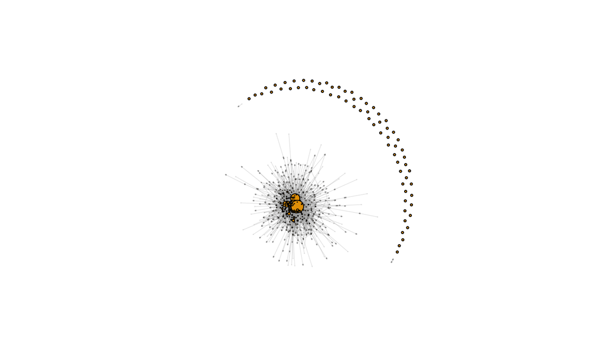

## COMMUNICATE

In summarizing our findings, lets return to our original research questions: *To what extent did educators engage with other participants in the discussion forums?* // *Were there differences in engagement across the two cohorts of educators?*